# Homework 2

## 9.11 Exercises – Problem 2

## A classic example of a non-stationary series are stock prices. Plot the daily closing prices for Amazon stock (contained in gafa_stock), along with the ACF and PACF. Explain how each plot shows that the series is non-stationary and should be differenced.

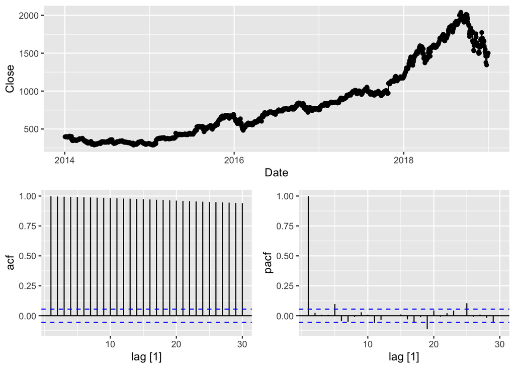

```r
# plot the data
amzn_stock <- gafa_stock %>%
  filter(Symbol == "AMZN")

amzn_stock %>%
  gg_tsdisplay(Close, plot_type = "partial")
```

```r
  labs(title = "Amazon Closing Stock Price")
```

```
## $title
## [1] "Amazon Closing Stock Price"
##
## attr(,"class")
## [1] "labels"
```

### Comment

From the time plot of stock price, the time series seems to have an increasing trend, which makes it non-stationary. The ACF plot shows a slightly decreasing pattern and has $lag_1$ with the largest and positive value, whereas all the lags are far beyond the ACF boundaries, which means that the data is not distributed as white noise and is not stationary. As for PACF plot, the large initial spike also indicates that the data is not stationary, so it should be difference to make it stationary.

## 9.11 Exercises – Problem 15

## Consider the number of Snowshoe Hare furs traded by the Hudson Bay Company between 1845 and 1935 (data set pelt).

### a. Produce a time plot of the time series.

```
## Plot variable not specified, automatically selected `.vars = Hare`
```

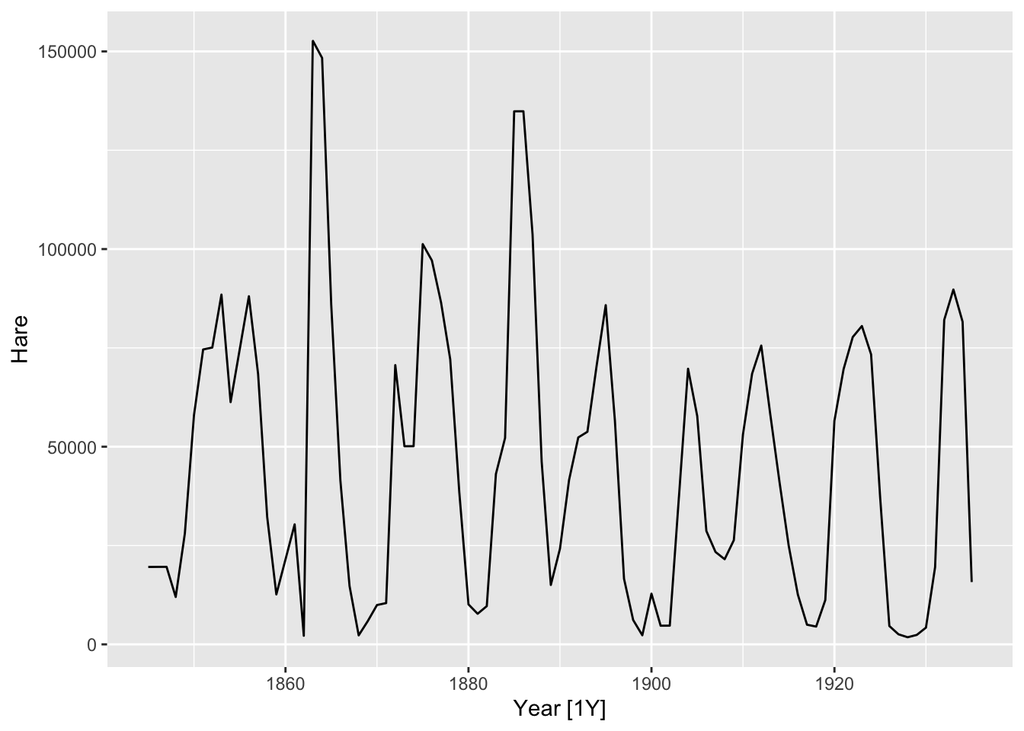

```r
pelt <- pelt

# plot the data
pelt %>%
  autoplot()
```

### b. Assume you decide to fit the following model:

$y_t$ = $c$ + $\phi_1$$y_{t-1}$ + $\phi_2$$y_{t-2}$ + $\phi_3$$y_{t-3}$ + $\phi_4$$y_{t-4}$ + $\varepsilon_t$ where $\varepsilon_t$ is a white noise series.

### What sort of ARIMA model is this (i.e., what are p, d, and q)?

```r
fit_pelt <- pelt %>%
  model(ARIMA(Hare)) %>%
  report(fit_pelt)
```

```
## Series: Hare
## Model: ARIMA(2,0,1) w/ mean
##
## Coefficients:
##          ar1      ar2      ma1   constant
##       1.3811  -0.7120  -0.5747  14936.234
## s.e.  0.1016   0.0784   0.1240   1072.719
##
## sigma^2 estimated as 583278195:  log likelihood=-1046.07
## AIC=2102.15   AICc=2102.85   BIC=2114.7
```

### c. By examining the ACF and PACF of the data, explain why this model is appropriate.

```
## Plot variable not specified, automatically selected `y = Hare`
```

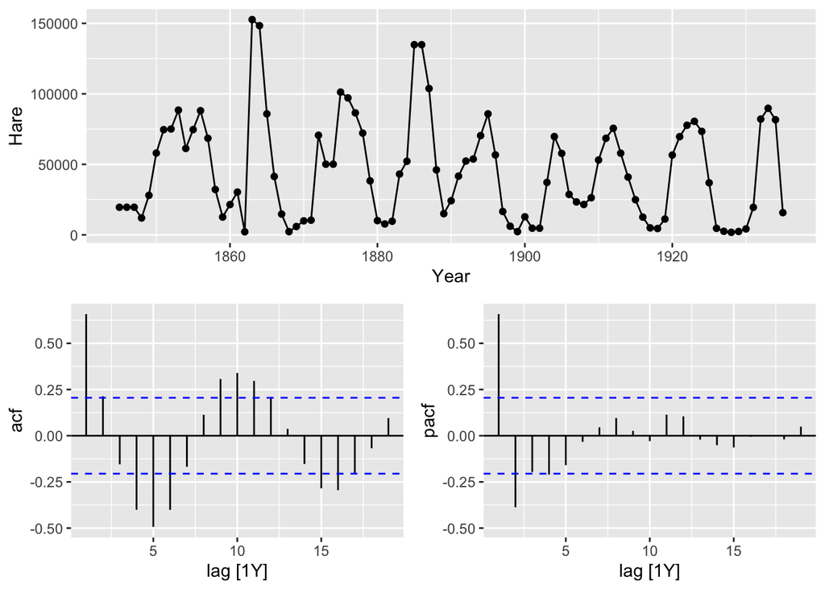

```r
gg_tsdisplay(pelt, plot_type = "partial")
```

#### Comment

The ACF plot shows decreasing autocorrelation and has strong lags on both direction, while PACT plot shows the $lag_1$ and $lag_2$ are above the bounds and slowly decreasing trend.

### d. The last five values of the series are given below:

The number of hare pelts is 19520 in 1931, 82110 in 1932, 89760 in 1933, 81660 in 1934 and 15760 in 1935.  
The estimated parameters are $c$ = 30993, $\phi_1$ = 0.82, $\phi_2$ = -0.29, $\phi_3$ = -0.01, and $\phi_4$ = -0.22.

### Without using the forecast(), calculate forecasts for the next three years (1936 - 1939).

```r
c = 30993
phi1 = 0.82
phi2 = -0.29
phi3 = -0.01
phi4 = -0.22

hares1931 = 19520
hares1932 = 82110
hares1933 = 89760
hares1934 = 81660
hares1935 = 15760

# calculate forecasts
hares1936 = c + phi1 * hares1935 + phi2 * hares1934 + phi3 * hares1933 + phi4 * hares1932
hares1937 = c + phi1 * hares1936 + phi2 * hares1935 + phi3 * hares1934 + phi4 * hares1933
hares1938 = c + phi1 * hares1937 + phi2 * hares1936 + phi3 * hares1935 + phi4 * hares1934

print(paste("The forecasts for the next 3 years (1936 - 1939) are", hares1936, ",", hares1937, ",", hares1938, "respectively."))
```

```
## [1] "The forecasts for the next 3 years (1936 - 1939) are 1273 , 6902.66 , 18161.2112 respectively."
```

### e. Now fit the model in R and obtain the forecasts using forecast(). How are they different from yours? Why?

```r
fit_pelt %>%
  forecast(h = 3)
```

```
## # A fable: 3 x 4 [1Y]
## # Key:     .model [1]
##   .model       Year              Hare  .mean
##   <chr>       <dbl>            <dist>  <dbl>
## 1 ARIMA(Hare)  1936  N(6634, 5.8e+08)  6634.
## 2 ARIMA(Hare)  1937 N(12878, 9.6e+08) 12878.
## 3 ARIMA(Hare)  1938 N(27999, 1.1e+09) 27999.
```